# Introduction

This dataset was obtained by scraping data from online reviews of different cannabis strains. It contains information on 2170 strains, mostly pertaining to their physiological and psychological effects, as well as their flavour profile. This is an exploratory analysis examining correlations between strain flavours and the medicinal effects, to investigate whether flavour might be a proxy for the underlying chemical profile.

For the scripts used to generate the data and more information on the project, see the [corresponding GitHub repository](https://github.com/MihaiChelaru/cannabis-strains).

## Loading the data and preliminary analysis

```python
%matplotlib inline

import pandas as pd
import numpy as np
import matplotlib.pyplot as plt
```

```python
df = pd.read_csv('Results/StrainScrape_full_2018-10-23.csv', low_memory=False)
print(df.shape)
df.head()
```

```
(2170, 84)
```

|  | Strain Name | Species | Review Count | Rating Value | Pain | Euphoric | Fatigue | Paranoid | Focused | Spasticity | ... | Spicy/Herbal | Woody | Blueberry | Sweet | Lavender | Nutty | Apricot | Diesel | Menthol | Mango |
| --- | --- | --- | --- | --- | --- | --- | --- | --- | --- | --- | --- | --- | --- | --- | --- | --- | --- | --- | --- | --- | --- |
| 0 | White Fire OG | hybrid | 650 | 4.5 | 61.287931 | 94.691754 | 0.000000 | 23.969588 | 0.0 | 0.0 | ... | 0 | 0 | 0 | 1 | 0 | 0 | 0 | 0 | 0 | 0 |
| 1 | Ice | hybrid | 167 | 4.1 | 84.145806 | 94.188232 | 60.254721 | 45.435467 | 0.0 | 0.0 | ... | 0 | 0 | 0 | 0 | 0 | 0 | 0 | 0 | 1 | 0 |
| 2 | Ghost OG | hybrid | 407 | 4.5 | 96.972863 | 69.354634 | 0.000000 | 24.476122 | 0.0 | 0.0 | ... | 0 | 0 | 0 | 0 | 0 | 0 | 0 | 0 | 0 | 0 |
| 3 | Sour Diesel | sativa | 5110 | 4.4 | 66.895824 | 72.064745 | 39.767464 | 37.301937 | 0.0 | 0.0 | ... | 0 | 0 | 0 | 0 | 0 | 0 | 0 | 1 | 0 | 0 |
| 4 | Granddaddy Purple | indica | 3169 | 4.4 | 85.895787 | 66.075548 | 0.000000 | 0.000000 | 0.0 | 0.0 | ... | 0 | 0 | 0 | 1 | 0 | 0 | 0 | 0 | 0 | 0 |

5 rows × 84 columns

```python
def display_all(df):
    with pd.option_context("display.max_rows", 1000, "display.max_columns", 1000):
        display(df)
```

```python
display_all(df.head(10).T)
```

|  | 0 | 1 | 2 | 3 | 4 | 5 | 6 | 7 | 8 | 9 |
| --- | --- | --- | --- | --- | --- | --- | --- | --- | --- | --- |
| Strain Name | White Fire OG | Ice | Ghost OG | Sour Diesel | Granddaddy Purple | Moby Dick | Lost Sierra Night Nurse | Golden Calyx | Broke Diesel | Lake of Fire |
| Species | hybrid | hybrid | hybrid | sativa | indica | sativa | hybrid | sativa | hybrid | hybrid |
| Review Count | 650 | 167 | 407 | 5110 | 3169 | 444 | 1 | 4 | 2 | 43 |
| Rating Value | 4.5 | 4.1 | 4.5 | 4.4 | 4.4 | 4.3 | 5 | 5 | 5 | 4.5 |
| Pain | 61.2879 | 84.1458 | 96.9729 | 66.8958 | 85.8958 | 55.1302 | 100 | 100 | 50 | 89.5522 |
| Euphoric | 94.6918 | 94.1882 | 69.3546 | 72.0647 | 66.0755 | 91.4967 | 0 | 0 | 100 | 0 |
| Fatigue | 0 | 60.2547 | 0 | 39.7675 | 0 | 36.2294 | 0 | 0 | 0 | 41.4179 |
| Paranoid | 23.9696 | 45.4355 | 24.4761 | 37.3019 | 0 | 29.8955 | 0 | 0 | 0 | 0 |
| Focused | 0 | 0 | 0 | 0 | 0 | 0 | 100 | 0 | 0 | 0 |
| Spasticity | 0 | 0 | 0 | 0 | 0 | 0 | 0 | 0 | 0 | 0 |
| Nausea | 0 | 36.9785 | 0 | 0 | 0 | 0 | 0 | 0 | 100 | 0 |
| Tingly | 0 | 0 | 0 | 0 | 0 | 0 | 0 | 0 | 0 | 0 |
| Headache | 30.738 | 42.9171 | 0 | 0 | 7.05886 | 0 | 0 | 100 | 100 | 0 |
| Dry Mouth | 100 | 100 | 100 | 100 | 100 | 100 | 100 | 50 | 0 | 100 |
| Aroused | 0 | 0 | 0 | 0 | 0 | 0 | 0 | 0 | 0 | 0 |
| Happy | 79.0802 | 0 | 68.1324 | 100 | 61.6102 | 87.6875 | 100 | 75 | 50 | 96.8531 |
| Muscle Spasms | 49.4108 | 0 | 0 | 0 | 0 | 0 | 100 | 100 | 0 | 0 |
| Uplifted | 79.5233 | 100 | 42.9568 | 79.9488 | 0 | 100 | 100 | 75 | 100 | 94.3357 |
| Anxious | 0 | 0 | 17.6838 | 33.5562 | 10.8486 | 38.3118 | 0 | 0 | 0 | 12.3567 |
| Energetic | 0 | 82.7237 | 0 | 80.3248 | 0 | 84.1824 | 100 | 75 | 50 | 0 |
| Headaches | 0 | 0 | 0 | 0 | 0 | 0 | 100 | 100 | 0 | 41.4179 |
| Depression | 86.0222 | 85.2437 | 68.6635 | 90.4184 | 61.6389 | 75.8337 | 0 | 0 | 0 | 0 |
| Giggly | 0 | 0 | 0 | 0 | 0 | 0 | 0 | 0 | 0 | 0 |
| Talkative | 0 | 90.039 | 0 | 0 | 0 | 0 | 0 | 0 | 0 | 0 |
| Dizzy | 22.5104 | 47.1144 | 15.8149 | 28.0802 | 22.9525 | 25.6945 | 0 | 0 | 0 | 2.29299 |
| Insomnia | 0 | 0 | 60.5402 | 0 | 81.5099 | 0 | 0 | 0 | 50 | 0 |
| Inflammation | 0 | 0 | 0 | 0 | 0 | 0 | 100 | 0 | 0 | 0 |
| Stress | 100 | 100 | 100 | 100 | 100 | 100 | 0 | 100 | 100 | 100 |
| Relaxed | 100 | 0 | 100 | 0 | 100 | 74.6979 | 0 | 100 | 0 | 100 |
| Seizures | 0 | 0 | 0 | 0 | 0 | 0 | 0 | 0 | 0 | 0 |

[output cut: 54 more lines]

As you can see, the majority of the columns are numeric. The values for each of the effects are based on prevalence of those effects in self-reported reviews of customers. For each strain, there are at most 5 effects in 3 parent categories: Effects, Medical, and Negatives.

- Effects refers to positive side effects, mostly pertaining to the mood it seems to elicit.
- Medical refers to what medicinal properties the cannabis strain exhibits, also self-reported, and this is perhaps the most interesting class of information in this dataset.
- Negatives are the negative side effects, such as Dry Mouth, Dry Eyes, Dizzy, Anxious, and Paranoid. These are also interesting because they may contribute negatively to the reviews for a particular strain.

The data is stored in a sparse matrix representation, which unfortunately means that there are a lot of zeroes for each strain. This is because the source of the data only displayed at most 15 effects and 3 flavours, even though the two together make up 80 columns.

```python
display_all(df.describe(include='all').T)
```

|  | count | unique | top | freq | mean | std | min | 25% | 50% | 75% | max |
| --- | --- | --- | --- | --- | --- | --- | --- | --- | --- | --- | --- |
| Strain Name | 2170 | 2168 | Blue Trainwreck | 2 | NaN | NaN | NaN | NaN | NaN | NaN | NaN |
| Species | 2170 | 3 | hybrid | 1119 | NaN | NaN | NaN | NaN | NaN | NaN | NaN |
| Review Count | 2170 | NaN | NaN | NaN | 101.154 | 354.493 | 0 | 8 | 23 | 66 | 8967 |
| Rating Value | 2170 | NaN | NaN | NaN | 4.45134 | 0.317741 | 1 | 4.3 | 4.5 | 4.6 | 5 |
| Pain | 2170 | NaN | NaN | NaN | 55.0895 | 39.7858 | 0 | 6.00376 | 63.6395 | 96.7019 | 100 |
| Euphoric | 2170 | NaN | NaN | NaN | 53.0109 | 38.5489 | 0 | 0 | 61.3702 | 89.9781 | 100 |
| Fatigue | 2170 | NaN | NaN | NaN | 21.0022 | 32.7622 | 0 | 0 | 0 | 43.0086 | 100 |
| Paranoid | 2170 | NaN | NaN | NaN | 15.2524 | 26.4027 | 0 | 0 | 0.835342 | 19.3075 | 100 |
| Focused | 2170 | NaN | NaN | NaN | 18.938 | 34.0289 | 0 | 0 | 0 | 27.2967 | 100 |
| Spasticity | 2170 | NaN | NaN | NaN | 1.52623 | 10.9513 | 0 | 0 | 0 | 0 | 100 |
| Nausea | 2170 | NaN | NaN | NaN | 11.3972 | 26.5554 | 0 | 0 | 0 | 0 | 100 |
| Tingly | 2170 | NaN | NaN | NaN | 9.1086 | 24.3204 | 0 | 0 | 0 | 0 | 100 |
| Headache | 2170 | NaN | NaN | NaN | 11.1038 | 24.2676 | 0 | 0 | 0 | 7.61521 | 100 |
| Dry Mouth | 2170 | NaN | NaN | NaN | 78.8721 | 36.7236 | 0 | 70.9102 | 100 | 100 | 100 |
| Aroused | 2170 | NaN | NaN | NaN | 5.59329 | 19.3749 | 0 | 0 | 0 | 0 | 100 |
| Happy | 2170 | NaN | NaN | NaN | 66.4613 | 36.4835 | 0 | 47.5443 | 79.4456 | 100 | 100 |
| Muscle Spasms | 2170 | NaN | NaN | NaN | 10.3848 | 25.9315 | 0 | 0 | 0 | 0 | 100 |
| Uplifted | 2170 | NaN | NaN | NaN | 46.8112 | 39.3594 | 0 | 0 | 51.9116 | 84.1309 | 100 |
| Anxious | 2170 | NaN | NaN | NaN | 15.5243 | 27.9466 | 0 | 0 | 0 | 17.9389 | 100 |
| Energetic | 2170 | NaN | NaN | NaN | 21.1301 | 35.8513 | 0 | 0 | 0 | 49.3576 | 100 |
| Headaches | 2170 | NaN | NaN | NaN | 17.5555 | 30.8287 | 0 | 0 | 0 | 29.8434 | 100 |
| Depression | 2170 | NaN | NaN | NaN | 60.0166 | 37.6896 | 0 | 25 | 69.7116 | 96.7412 | 100 |
| Giggly | 2170 | NaN | NaN | NaN | 8.41132 | 23.7222 | 0 | 0 | 0 | 0 | 100 |
| Talkative | 2170 | NaN | NaN | NaN | 10.8754 | 26.8456 | 0 | 0 | 0 | 0 | 100 |
| Dizzy | 2170 | NaN | NaN | NaN | 20.5998 | 30.7883 | 0 | 0 | 4.83342 | 28.5714 | 100 |
| Insomnia | 2170 | NaN | NaN | NaN | 31.5501 | 38.9458 | 0 | 0 | 0 | 68.1631 | 100 |
| Inflammation | 2170 | NaN | NaN | NaN | 11.9453 | 27.3317 | 0 | 0 | 0 | 0 | 100 |
| Stress | 2170 | NaN | NaN | NaN | 75.7854 | 36.4456 | 0 | 60.8961 | 100 | 100 | 100 |
| Relaxed | 2170 | NaN | NaN | NaN | 69.1694 | 41.2664 | 0 | 30.3777 | 96.5619 | 100 | 100 |
| Seizures | 2170 | NaN | NaN | NaN | 0.804359 | 7.74212 | 0 | 0 | 0 | 0 | 100 |

[output cut: 54 more lines]

## Preliminary data visualizations

We can do some preliminary visualizations in order to examine various distributions, for instance rating, review count, species, as well as the average values of the different effects and flavours to see how prevalent they are overall. We can then examine these by different flavours, for instance, to see which effects are most prevalent for a particular flavour.

### Strains by species

```python
from plotly.offline import init_notebook_mode, iplot
import plotly.graph_objs as go

init_notebook_mode(connected=True)

data = [go.Histogram(x=df.Species)]

iplot(data, filename='strains-by-species')
```

[interactive chart not shown]

### Bar plots of effects and flavours

```python
def plot_bar(df, cols, metric='mean'):
    '''Generates a plotly bar graph with the given metric over the given column names.'''
    if metric == 'sum':
        col_vals = df[cols].sum()
    elif metric == 'mean':
        col_vals = df[cols].mean()

    data = [dict(
        type ='bar',
        x = cols,
        y = col_vals,
        transforms = [dict(
            type = 'sort',
            target = 'y',
            order = 'descending'
        )]
    )]

    iplot(data, validate=False)
```

```python
flavours = ['Orange', 'Violet', 'Mint', 'Peach', 'Chestnut', 'Rose', 'Coffee', 'Citrus',
        'Lime', 'Plum', 'Sage', 'Pine', 'Pungent', 'Pear', 'Tar', 'Tree Fruit', 'Berry', 'Vanilla', 'Pepper',
        'Chemical', 'Tea', 'Ammonia', 'Apple', 'Skunk', 'Pineapple', 'Grapefruit', 'Honey', 'Earthy', 'Cheese',
        'Blue Cheese', 'Tropical', 'Grape', 'Lemon', 'Flowery', 'Strawberry', 'Butter', 'Tobacco', 'Spicy/Herbal',
        'Woody', 'Blueberry', 'Sweet', 'Lavender', 'Nutty', 'Apricot', 'Diesel', 'Menthol', 'Mango']
```

```python
plot_bar(df, flavours, metric='sum')
```

[interactive chart not shown]

```python
effects = ['Pain', 'Euphoric', 'Fatigue', 'Paranoid',
        'Focused', 'Spasticity', 'Nausea', 'Tingly', 'Headache', 'Dry Mouth', 'Aroused', 'Happy', 'Muscle Spasms',
        'Uplifted', 'Anxious', 'Energetic', 'Headaches', 'Depression', 'Giggly', 'Talkative', 'Dizzy', 'Insomnia',
        'Inflammation', 'Stress', 'Relaxed', 'Seizures', 'Cramps', 'Sleepy', 'Hungry', 'Lack of Appetite', 'Dry Eyes',
        'Creative', 'Eye Pressure']
```

```python
plot_bar(df, effects)
```

[interactive chart not shown]

```python
positives = ['Euphoric', 'Focused', 'Uplifted', 'Energetic', 'Giggly', 'Tingly',
             'Talkative', 'Relaxed', 'Creative', 'Hungry', 'Happy', 'Aroused', 'Sleepy']
plot_bar(df, positives)
```

[interactive chart not shown]

```python
medical = ['Stress', 'Pain', 'Depression', 'Lack of Appetite', 'Fatigue', 'Inflammation', 'Insomnia',
          'Seizures', 'Muscle Spasms', 'Cramps', 'Nausea', 'Headaches']
plot_bar(df, medical)
```

[interactive chart not shown]

```python
negatives = ['Dry Mouth', 'Dry Eyes', 'Dizzy', 'Anxious', 'Paranoid', 'Eye Pressure', 'Headache',
            'Spasticity']
plot_bar(df, negatives)
```

[interactive chart not shown]

```python
data = [go.Histogram(x=df['Rating Value'])]

iplot(data)
```

[interactive chart not shown]

### Ratings by species

```python
import plotly.figure_factory as ff

def plot_facet(df, x, facet_row):
    fig = ff.create_facet_grid(
        df,
        x=x,
        facet_row=facet_row,
        trace_type='histogram',
    )
    iplot(fig)
```

```python
plot_facet(df, 'Rating Value', 'Species')
```

[interactive chart not shown]

### Effects and flavours by species

```python
def species_barplot(df, x, aggr='mean'):
    grouped = df[x + ['Species']].groupby('Species').agg(aggr).T

    trace1 = go.Bar(
        x=x,
        y=grouped['indica'],
        name='indica'
    )
    trace2 = go.Bar(
        x=x,
        y=grouped['sativa'],
        name='sativa'
    )
    trace3 = go.Bar(
        x=x,
        y=grouped['hybrid'],
        name='hybrid'
    )

    data = [trace1, trace2, trace3]
    layout = go.Layout(
        barmode='group'
    )

    fig = go.Figure(data=data, layout=layout)
    iplot(fig)
```

```python
df[positives + ['Species']].groupby('Species').agg('mean').T
```

| Species | hybrid | indica | sativa |
| --- | --- | --- | --- |
| Euphoric | 53.991500 | 50.653793 | 54.069454 |
| Focused | 21.465986 | 8.464595 | 28.708946 |
| Uplifted | 51.486174 | 28.339362 | 63.444578 |
| Energetic | 19.906676 | 3.912307 | 52.092848 |
| Giggly | 8.946909 | 7.437736 | 8.487049 |
| Tingly | 9.243621 | 11.050779 | 5.624274 |
| Talkative | 12.754411 | 4.946600 | 15.166047 |
| Relaxed | 70.511745 | 87.654231 | 35.848099 |
| Creative | 25.549787 | 10.458199 | 34.982216 |
| Hungry | 13.218395 | 20.755591 | 8.030956 |
| Happy | 68.719084 | 58.953970 | 72.230374 |
| Aroused | 5.500010 | 5.512875 | 5.980434 |
| Sleepy | 13.259266 | 47.725449 | 4.062139 |

```python
species_barplot(df, positives)
```

[interactive chart not shown]

```python
species_barplot(df, medical)
```

[interactive chart not shown]

```python
species_barplot(df, negatives)
```

[interactive chart not shown]

```python
species_barplot(df, flavours)
```

[interactive chart not shown]

### Review count by species

```python
species_barplot(df, ['Review Count'], aggr='sum')
```

[interactive chart not shown]

## Hierarchical clustering

### Clustering features by rank correlation

We can use hierarchical clustering combined with the Spearman rank correlation function `spearmanr` to see if there are natural groupings of flavours and effects according to these metrics. This can give us an idea of both what interesting relationships may exist, and whether our results make sense as a sanity check if we see similar items clustered together.

```python
import scipy
from scipy.cluster import hierarchy as hc

def plot_dendrogram(columns):
    corr = np.round(scipy.stats.spearmanr(df.loc[:, columns]).correlation, 4)
    corr_condensed = hc.distance.squareform(1-corr)
    z = hc.linkage(corr_condensed, method='ward')
    fig = plt.figure(figsize=(20,20))
    dendrogram = hc.dendrogram(z, labels=columns, orientation='left', color_threshold=1.2, leaf_font_size=16)
    plt.show()
```

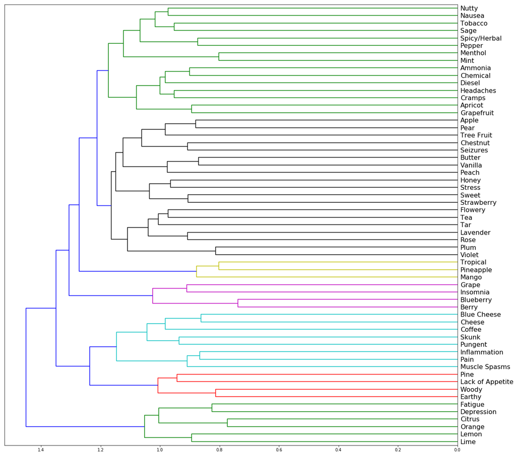

```python
cols = medical+flavours
plot_dendrogram(cols)
```

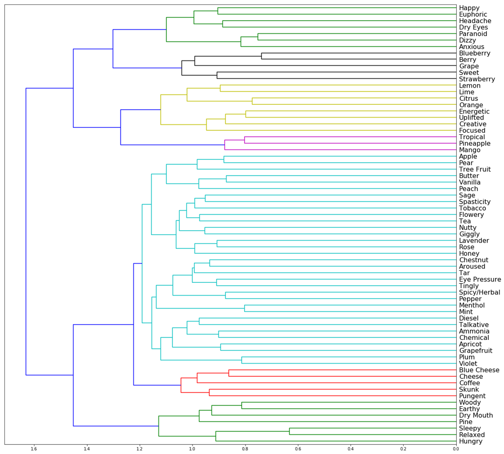

```python
cols = positives+negatives+flavours
plot_dendrogram(cols)
```

### Seaborn heatmap of correlations

Another way to visualize relationships between two sets of variables is to use a heatmap to look at the relative correlations. This way you can look for any bright patches within a particular row or column to see if there are stronger associations between any of the flavours and their corresponding medicinal effects.

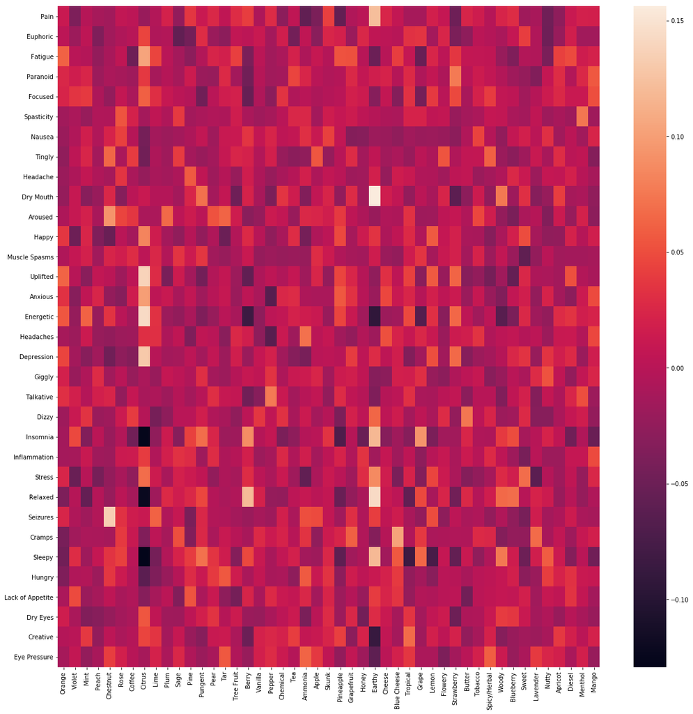

```python
import seaborn as sns
corr = df.corr().iloc[2:35, 35:]
fig2 = plt.figure(figsize=(20,20))
sns.heatmap(corr,
            xticklabels=corr.columns.values,
            yticklabels=corr.index.values)
plt.show()
```

## Examining effects for top flavours

We can look at the associated medicinal effects of the three most dominant flavours, Earthy, Citrus, and Sweet, to see which ones appear to be over- or under-represented.

### Barplots of earthy, citrus, and sweet flavours vs effects

```python
def flavour_barplot(df, x, aggr='mean'):
    earthy = df[x].loc[df['Earthy'] == 1].agg(aggr).T
    citrus = df[x].loc[df['Citrus'] == 1].agg(aggr).T
    sweet = df[x].loc[df['Sweet'] == 1].agg(aggr).T

    trace1 = go.Bar(
        x=x,
        y=earthy,
        name='Earthy'
    )
    trace2 = go.Bar(
        x=x,
        y=citrus,
        name='Citrus'
    )
    trace3 = go.Bar(
        x=x,
        y=sweet,
        name='Sweet'
    )

    data = [trace1, trace2, trace3]
    layout = go.Layout(
        barmode='group'
    )

    fig = go.Figure(data=data, layout=layout)
    iplot(fig)
```

```python
flavour_barplot(df, positives)
```

[interactive chart not shown]

```python
flavour_barplot(df, medical)
```

[interactive chart not shown]

```python
flavour_barplot(df, negatives)
```

[interactive chart not shown]

```python
flavour_barplot(df, medical, aggr='sum')
```

[interactive chart not shown]

```python
flavour_barplot(df, positives, aggr='sum')
```

[interactive chart not shown]

```python
flavour_barplot(df, negatives, aggr='sum')
```

[interactive chart not shown]

## Ranking top flavours for each effect

We can also get a count of the number of times each effect appears together with every flavour in order to examine which pairings are most common. Then instead of using absolute numbers, we can rank these associations and try to see which pairings deviate from the norm using a heatmap. First, we'll need to calculate the number of times each effect is non-zero in the same row as each of the individual flavours. Here's an example using just `Dry Mouth`.

```python
col = df[df['Dry Mouth'] > 0].astype(bool).sum(axis=0)[37:]
col
```

```
Orange            66
Violet             7
Mint              44
Peach              2
Chestnut           4
Rose              16
Coffee            25
Citrus           491
Lime              44
Plum               4
Sage              35
Pine             270
Pungent          370
Pear               2
Tar                6
Tree Fruit        26
Berry            309
Vanilla           23
Pepper            44
Chemical          35
Tea               12
Ammonia           15
Apple             20
Skunk            148
Pineapple         38
Grapefruit        27
Honey             24
Earthy          1008
Cheese            51
Blue Cheese        8
Tropical         132
Grape             91
Lemon            182
Flowery          233
Strawberry        37
Butter            14
Tobacco            7
Spicy/Herbal     207
Woody            265
Blueberry        143
Sweet            848
Lavender          32
Nutty             28
Apricot           11
Diesel           213
Menthol           13
Mango             25
dtype: int64
```

We can generalize this example and create a function that will allow us to create one such column for every one of our medicinal effects, in effect finding the number of times each pairing of effect and flavour appears in our dataset.

```python
def sum_across_cols(df, effects):
    cols = []
    for effect in effects:
        cols.append(df[df[effect] > 0].astype(bool).sum(axis=0)[37:])
    new_df = pd.concat(cols, axis=1)
    new_df.columns = effects
    return new_df
```

```python
sum_df = sum_across_cols(df, effects)
sum_df
```

|  | Pain | Euphoric | Fatigue | Paranoid | Focused | Spasticity | Nausea | Tingly | Headache | Dry Mouth | ... | Stress | Relaxed | Seizures | Cramps | Sleepy | Hungry | Lack of Appetite | Dry Eyes | Creative | Eye Pressure |
| --- | --- | --- | --- | --- | --- | --- | --- | --- | --- | --- | --- | --- | --- | --- | --- | --- | --- | --- | --- | --- | --- |
| Orange | 58 | 52 | 43 | 40 | 23 | 1 | 11 | 8 | 28 | 66 | ... | 68 | 49 | 2 | 1 | 15 | 12 | 28 | 61 | 25 | 6 |
| Violet | 5 | 4 | 2 | 4 | 3 | 0 | 2 | 1 | 3 | 7 | ... | 4 | 6 | 0 | 0 | 4 | 1 | 4 | 4 | 3 | 2 |
| Mint | 39 | 39 | 22 | 25 | 18 | 0 | 13 | 9 | 22 | 44 | ... | 47 | 33 | 0 | 4 | 14 | 9 | 17 | 37 | 21 | 3 |
| Peach | 2 | 1 | 0 | 1 | 1 | 0 | 1 | 0 | 1 | 2 | ... | 1 | 2 | 0 | 0 | 1 | 0 | 1 | 1 | 0 | 0 |
| Chestnut | 3 | 2 | 1 | 2 | 0 | 0 | 1 | 2 | 1 | 4 | ... | 3 | 2 | 1 | 0 | 2 | 2 | 1 | 2 | 1 | 1 |
| Rose | 13 | 14 | 6 | 7 | 5 | 2 | 6 | 3 | 8 | 16 | ... | 16 | 15 | 1 | 3 | 10 | 5 | 7 | 14 | 5 | 3 |
| Coffee | 22 | 21 | 6 | 11 | 7 | 1 | 6 | 7 | 12 | 25 | ... | 24 | 20 | 2 | 3 | 10 | 7 | 11 | 21 | 9 | 4 |
| Citrus | 418 | 400 | 248 | 285 | 163 | 11 | 97 | 57 | 207 | 491 | ... | 494 | 378 | 6 | 34 | 119 | 93 | 187 | 460 | 202 | 51 |
| Lime | 37 | 33 | 25 | 21 | 17 | 1 | 7 | 7 | 19 | 44 | ... | 43 | 34 | 2 | 4 | 10 | 6 | 15 | 40 | 20 | 6 |
| Plum | 4 | 3 | 1 | 2 | 2 | 0 | 0 | 0 | 2 | 4 | ... | 4 | 4 | 0 | 0 | 2 | 0 | 1 | 3 | 1 | 1 |
| Sage | 29 | 23 | 16 | 19 | 10 | 3 | 5 | 10 | 13 | 35 | ... | 36 | 36 | 1 | 7 | 16 | 9 | 10 | 27 | 13 | 7 |
| Pine | 231 | 207 | 98 | 166 | 79 | 5 | 59 | 36 | 136 | 270 | ... | 259 | 230 | 0 | 17 | 110 | 74 | 124 | 251 | 89 | 25 |
| Pungent | 315 | 307 | 146 | 215 | 94 | 8 | 79 | 54 | 168 | 370 | ... | 353 | 321 | 7 | 36 | 160 | 100 | 142 | 337 | 115 | 29 |
| Pear | 3 | 1 | 2 | 0 | 1 | 0 | 0 | 0 | 0 | 2 | ... | 2 | 2 | 0 | 0 | 2 | 2 | 1 | 3 | 1 | 0 |
| Tar | 4 | 4 | 5 | 4 | 2 | 0 | 1 | 1 | 3 | 6 | ... | 5 | 4 | 0 | 1 | 2 | 3 | 1 | 5 | 2 | 2 |
| Tree Fruit | 26 | 26 | 14 | 11 | 10 | 1 | 7 | 6 | 10 | 26 | ... | 28 | 24 | 0 | 2 | 6 | 7 | 5 | 23 | 11 | 2 |
| Berry | 273 | 257 | 103 | 163 | 72 | 7 | 78 | 55 | 129 | 309 | ... | 310 | 296 | 3 | 23 | 138 | 83 | 125 | 273 | 97 | 23 |
| Vanilla | 21 | 22 | 9 | 14 | 6 | 0 | 9 | 5 | 9 | 23 | ... | 25 | 22 | 0 | 4 | 11 | 8 | 10 | 20 | 11 | 4 |
| Pepper | 46 | 39 | 18 | 23 | 10 | 1 | 13 | 12 | 16 | 44 | ... | 49 | 40 | 0 | 7 | 17 | 9 | 25 | 43 | 24 | 10 |
| Chemical | 23 | 27 | 15 | 20 | 13 | 1 | 10 | 3 | 10 | 35 | ... | 31 | 25 | 1 | 5 | 14 | 7 | 14 | 32 | 14 | 4 |
| Tea | 11 | 6 | 5 | 12 | 3 | 1 | 4 | 0 | 5 | 12 | ... | 11 | 10 | 0 | 1 | 5 | 1 | 5 | 11 | 8 | 1 |
| Ammonia | 9 | 15 | 7 | 10 | 7 | 1 | 6 | 2 | 6 | 15 | ... | 12 | 16 | 1 | 6 | 6 | 7 | 7 | 11 | 6 | 4 |
| Apple | 14 | 14 | 10 | 9 | 5 | 0 | 5 | 6 | 8 | 20 | ... | 18 | 17 | 1 | 0 | 5 | 6 | 6 | 17 | 7 | 3 |
| Skunk | 126 | 119 | 51 | 89 | 45 | 5 | 37 | 18 | 69 | 148 | ... | 143 | 125 | 3 | 13 | 60 | 43 | 61 | 141 | 62 | 14 |
| Pineapple | 29 | 36 | 28 | 27 | 13 | 1 | 13 | 6 | 17 | 38 | ... | 42 | 29 | 0 | 5 | 4 | 5 | 14 | 34 | 21 | 2 |
| Grapefruit | 20 | 17 | 14 | 18 | 9 | 1 | 3 | 7 | 10 | 27 | ... | 22 | 20 | 1 | 7 | 8 | 7 | 9 | 27 | 5 | 3 |
| Honey | 22 | 23 | 11 | 12 | 9 | 1 | 3 | 2 | 8 | 24 | ... | 27 | 21 | 1 | 2 | 8 | 7 | 11 | 19 | 13 | 3 |
| Earthy | 868 | 807 | 371 | 608 | 271 | 24 | 199 | 154 | 496 | 1008 | ... | 965 | 880 | 18 | 78 | 416 | 254 | 409 | 924 | 313 | 80 |
| Cheese | 41 | 38 | 21 | 34 | 16 | 1 | 9 | 5 | 19 | 51 | ... | 48 | 43 | 1 | 4 | 17 | 14 | 25 | 47 | 21 | 4 |
| Blue Cheese | 6 | 5 | 4 | 3 | 0 | 0 | 0 | 1 | 4 | 8 | ... | 5 | 6 | 1 | 3 | 6 | 3 | 5 | 6 | 2 | 1 |
| Tropical | 115 | 116 | 58 | 75 | 45 | 5 | 27 | 17 | 58 | 132 | ... | 128 | 101 | 1 | 13 | 28 | 25 | 46 | 124 | 65 | 18 |
| Grape | 80 | 87 | 24 | 52 | 16 | 3 | 15 | 15 | 42 | 91 | ... | 89 | 92 | 0 | 11 | 47 | 24 | 34 | 86 | 31 | 11 |
| Lemon | 153 | 140 | 89 | 105 | 58 | 5 | 34 | 28 | 74 | 182 | ... | 178 | 148 | 5 | 13 | 42 | 36 | 69 | 162 | 74 | 20 |
| Flowery | 192 | 191 | 92 | 123 | 63 | 7 | 40 | 50 | 102 | 233 | ... | 227 | 202 | 2 | 22 | 88 | 57 | 92 | 203 | 85 | 17 |
| Strawberry | 30 | 28 | 22 | 24 | 19 | 0 | 6 | 5 | 16 | 37 | ... | 41 | 31 | 1 | 4 | 8 | 9 | 16 | 30 | 16 | 3 |
| Butter | 15 | 11 | 5 | 7 | 6 | 0 | 3 | 3 | 6 | 14 | ... | 14 | 14 | 0 | 2 | 8 | 4 | 2 | 14 | 4 | 1 |
| Tobacco | 7 | 7 | 2 | 5 | 3 | 0 | 3 | 1 | 4 | 7 | ... | 6 | 6 | 0 | 1 | 1 | 2 | 4 | 8 | 2 | 1 |
| Spicy/Herbal | 171 | 169 | 86 | 120 | 66 | 5 | 45 | 47 | 86 | 207 | ... | 205 | 186 | 1 | 25 | 78 | 51 | 83 | 183 | 84 | 34 |
| Woody | 226 | 206 | 95 | 164 | 74 | 5 | 46 | 38 | 130 | 265 | ... | 252 | 236 | 3 | 17 | 117 | 72 | 113 | 250 | 79 | 26 |
| Blueberry | 126 | 117 | 43 | 83 | 42 | 3 | 36 | 19 | 70 | 143 | ... | 137 | 139 | 1 | 10 | 61 | 43 | 56 | 136 | 47 | 12 |
| Sweet | 724 | 711 | 353 | 474 | 239 | 20 | 191 | 131 | 375 | 848 | ... | 846 | 723 | 9 | 74 | 285 | 197 | 350 | 773 | 303 | 91 |
| Lavender | 34 | 31 | 13 | 15 | 11 | 1 | 7 | 6 | 18 | 32 | ... | 32 | 33 | 1 | 7 | 17 | 6 | 12 | 32 | 12 | 6 |
| Nutty | 20 | 18 | 7 | 19 | 10 | 0 | 9 | 4 | 11 | 28 | ... | 29 | 27 | 0 | 2 | 15 | 11 | 12 | 23 | 8 | 4 |
| Apricot | 8 | 6 | 6 | 7 | 4 | 0 | 2 | 3 | 5 | 11 | ... | 9 | 8 | 0 | 1 | 4 | 3 | 4 | 8 | 5 | 2 |
| Diesel | 185 | 176 | 109 | 126 | 64 | 3 | 47 | 31 | 93 | 213 | ... | 217 | 189 | 3 | 19 | 67 | 62 | 96 | 197 | 89 | 20 |
| Menthol | 12 | 10 | 6 | 7 | 5 | 2 | 2 | 2 | 7 | 13 | ... | 14 | 10 | 0 | 2 | 4 | 5 | 7 | 12 | 5 | 2 |
| Mango | 21 | 23 | 13 | 16 | 12 | 0 | 7 | 2 | 7 | 25 | ... | 26 | 22 | 0 | 4 | 5 | 7 | 9 | 21 | 12 | 1 |

47 rows × 33 columns

We should also replace values of `0` with `NaN` instead, since we don't really want these to be part of our ranking, and it allows us to omit these pairings for which there is no data in our heatmap so we can differentiate between the lowest-ranked pairings that might have a single occurrence or a `1` and those with no data to support them.

```python
sum_df.replace(0, np.nan, inplace=True)
sum_df
```

|  | Pain | Euphoric | Fatigue | Paranoid | Focused | Spasticity | Nausea | Tingly | Headache | Dry Mouth | ... | Stress | Relaxed | Seizures | Cramps | Sleepy | Hungry | Lack of Appetite | Dry Eyes | Creative | Eye Pressure |
| --- | --- | --- | --- | --- | --- | --- | --- | --- | --- | --- | --- | --- | --- | --- | --- | --- | --- | --- | --- | --- | --- |
| Orange | 58 | 52 | 43.0 | 40.0 | 23.0 | 1.0 | 11.0 | 8.0 | 28.0 | 66 | ... | 68 | 49 | 2.0 | 1.0 | 15 | 12.0 | 28 | 61 | 25.0 | 6.0 |
| Violet | 5 | 4 | 2.0 | 4.0 | 3.0 | NaN | 2.0 | 1.0 | 3.0 | 7 | ... | 4 | 6 | NaN | NaN | 4 | 1.0 | 4 | 4 | 3.0 | 2.0 |
| Mint | 39 | 39 | 22.0 | 25.0 | 18.0 | NaN | 13.0 | 9.0 | 22.0 | 44 | ... | 47 | 33 | NaN | 4.0 | 14 | 9.0 | 17 | 37 | 21.0 | 3.0 |
| Peach | 2 | 1 | NaN | 1.0 | 1.0 | NaN | 1.0 | NaN | 1.0 | 2 | ... | 1 | 2 | NaN | NaN | 1 | NaN | 1 | 1 | NaN | NaN |
| Chestnut | 3 | 2 | 1.0 | 2.0 | NaN | NaN | 1.0 | 2.0 | 1.0 | 4 | ... | 3 | 2 | 1.0 | NaN | 2 | 2.0 | 1 | 2 | 1.0 | 1.0 |
| Rose | 13 | 14 | 6.0 | 7.0 | 5.0 | 2.0 | 6.0 | 3.0 | 8.0 | 16 | ... | 16 | 15 | 1.0 | 3.0 | 10 | 5.0 | 7 | 14 | 5.0 | 3.0 |
| Coffee | 22 | 21 | 6.0 | 11.0 | 7.0 | 1.0 | 6.0 | 7.0 | 12.0 | 25 | ... | 24 | 20 | 2.0 | 3.0 | 10 | 7.0 | 11 | 21 | 9.0 | 4.0 |
| Citrus | 418 | 400 | 248.0 | 285.0 | 163.0 | 11.0 | 97.0 | 57.0 | 207.0 | 491 | ... | 494 | 378 | 6.0 | 34.0 | 119 | 93.0 | 187 | 460 | 202.0 | 51.0 |
| Lime | 37 | 33 | 25.0 | 21.0 | 17.0 | 1.0 | 7.0 | 7.0 | 19.0 | 44 | ... | 43 | 34 | 2.0 | 4.0 | 10 | 6.0 | 15 | 40 | 20.0 | 6.0 |
| Plum | 4 | 3 | 1.0 | 2.0 | 2.0 | NaN | NaN | NaN | 2.0 | 4 | ... | 4 | 4 | NaN | NaN | 2 | NaN | 1 | 3 | 1.0 | 1.0 |
| Sage | 29 | 23 | 16.0 | 19.0 | 10.0 | 3.0 | 5.0 | 10.0 | 13.0 | 35 | ... | 36 | 36 | 1.0 | 7.0 | 16 | 9.0 | 10 | 27 | 13.0 | 7.0 |
| Pine | 231 | 207 | 98.0 | 166.0 | 79.0 | 5.0 | 59.0 | 36.0 | 136.0 | 270 | ... | 259 | 230 | NaN | 17.0 | 110 | 74.0 | 124 | 251 | 89.0 | 25.0 |
| Pungent | 315 | 307 | 146.0 | 215.0 | 94.0 | 8.0 | 79.0 | 54.0 | 168.0 | 370 | ... | 353 | 321 | 7.0 | 36.0 | 160 | 100.0 | 142 | 337 | 115.0 | 29.0 |
| Pear | 3 | 1 | 2.0 | NaN | 1.0 | NaN | NaN | NaN | NaN | 2 | ... | 2 | 2 | NaN | NaN | 2 | 2.0 | 1 | 3 | 1.0 | NaN |
| Tar | 4 | 4 | 5.0 | 4.0 | 2.0 | NaN | 1.0 | 1.0 | 3.0 | 6 | ... | 5 | 4 | NaN | 1.0 | 2 | 3.0 | 1 | 5 | 2.0 | 2.0 |
| Tree Fruit | 26 | 26 | 14.0 | 11.0 | 10.0 | 1.0 | 7.0 | 6.0 | 10.0 | 26 | ... | 28 | 24 | NaN | 2.0 | 6 | 7.0 | 5 | 23 | 11.0 | 2.0 |
| Berry | 273 | 257 | 103.0 | 163.0 | 72.0 | 7.0 | 78.0 | 55.0 | 129.0 | 309 | ... | 310 | 296 | 3.0 | 23.0 | 138 | 83.0 | 125 | 273 | 97.0 | 23.0 |
| Vanilla | 21 | 22 | 9.0 | 14.0 | 6.0 | NaN | 9.0 | 5.0 | 9.0 | 23 | ... | 25 | 22 | NaN | 4.0 | 11 | 8.0 | 10 | 20 | 11.0 | 4.0 |
| Pepper | 46 | 39 | 18.0 | 23.0 | 10.0 | 1.0 | 13.0 | 12.0 | 16.0 | 44 | ... | 49 | 40 | NaN | 7.0 | 17 | 9.0 | 25 | 43 | 24.0 | 10.0 |
| Chemical | 23 | 27 | 15.0 | 20.0 | 13.0 | 1.0 | 10.0 | 3.0 | 10.0 | 35 | ... | 31 | 25 | 1.0 | 5.0 | 14 | 7.0 | 14 | 32 | 14.0 | 4.0 |
| Tea | 11 | 6 | 5.0 | 12.0 | 3.0 | 1.0 | 4.0 | NaN | 5.0 | 12 | ... | 11 | 10 | NaN | 1.0 | 5 | 1.0 | 5 | 11 | 8.0 | 1.0 |
| Ammonia | 9 | 15 | 7.0 | 10.0 | 7.0 | 1.0 | 6.0 | 2.0 | 6.0 | 15 | ... | 12 | 16 | 1.0 | 6.0 | 6 | 7.0 | 7 | 11 | 6.0 | 4.0 |
| Apple | 14 | 14 | 10.0 | 9.0 | 5.0 | NaN | 5.0 | 6.0 | 8.0 | 20 | ... | 18 | 17 | 1.0 | NaN | 5 | 6.0 | 6 | 17 | 7.0 | 3.0 |
| Skunk | 126 | 119 | 51.0 | 89.0 | 45.0 | 5.0 | 37.0 | 18.0 | 69.0 | 148 | ... | 143 | 125 | 3.0 | 13.0 | 60 | 43.0 | 61 | 141 | 62.0 | 14.0 |
| Pineapple | 29 | 36 | 28.0 | 27.0 | 13.0 | 1.0 | 13.0 | 6.0 | 17.0 | 38 | ... | 42 | 29 | NaN | 5.0 | 4 | 5.0 | 14 | 34 | 21.0 | 2.0 |
| Grapefruit | 20 | 17 | 14.0 | 18.0 | 9.0 | 1.0 | 3.0 | 7.0 | 10.0 | 27 | ... | 22 | 20 | 1.0 | 7.0 | 8 | 7.0 | 9 | 27 | 5.0 | 3.0 |
| Honey | 22 | 23 | 11.0 | 12.0 | 9.0 | 1.0 | 3.0 | 2.0 | 8.0 | 24 | ... | 27 | 21 | 1.0 | 2.0 | 8 | 7.0 | 11 | 19 | 13.0 | 3.0 |
| Earthy | 868 | 807 | 371.0 | 608.0 | 271.0 | 24.0 | 199.0 | 154.0 | 496.0 | 1008 | ... | 965 | 880 | 18.0 | 78.0 | 416 | 254.0 | 409 | 924 | 313.0 | 80.0 |
| Cheese | 41 | 38 | 21.0 | 34.0 | 16.0 | 1.0 | 9.0 | 5.0 | 19.0 | 51 | ... | 48 | 43 | 1.0 | 4.0 | 17 | 14.0 | 25 | 47 | 21.0 | 4.0 |
| Blue Cheese | 6 | 5 | 4.0 | 3.0 | NaN | NaN | NaN | 1.0 | 4.0 | 8 | ... | 5 | 6 | 1.0 | 3.0 | 6 | 3.0 | 5 | 6 | 2.0 | 1.0 |
| Tropical | 115 | 116 | 58.0 | 75.0 | 45.0 | 5.0 | 27.0 | 17.0 | 58.0 | 132 | ... | 128 | 101 | 1.0 | 13.0 | 28 | 25.0 | 46 | 124 | 65.0 | 18.0 |
| Grape | 80 | 87 | 24.0 | 52.0 | 16.0 | 3.0 | 15.0 | 15.0 | 42.0 | 91 | ... | 89 | 92 | NaN | 11.0 | 47 | 24.0 | 34 | 86 | 31.0 | 11.0 |
| Lemon | 153 | 140 | 89.0 | 105.0 | 58.0 | 5.0 | 34.0 | 28.0 | 74.0 | 182 | ... | 178 | 148 | 5.0 | 13.0 | 42 | 36.0 | 69 | 162 | 74.0 | 20.0 |
| Flowery | 192 | 191 | 92.0 | 123.0 | 63.0 | 7.0 | 40.0 | 50.0 | 102.0 | 233 | ... | 227 | 202 | 2.0 | 22.0 | 88 | 57.0 | 92 | 203 | 85.0 | 17.0 |
| Strawberry | 30 | 28 | 22.0 | 24.0 | 19.0 | NaN | 6.0 | 5.0 | 16.0 | 37 | ... | 41 | 31 | 1.0 | 4.0 | 8 | 9.0 | 16 | 30 | 16.0 | 3.0 |
| Butter | 15 | 11 | 5.0 | 7.0 | 6.0 | NaN | 3.0 | 3.0 | 6.0 | 14 | ... | 14 | 14 | NaN | 2.0 | 8 | 4.0 | 2 | 14 | 4.0 | 1.0 |
| Tobacco | 7 | 7 | 2.0 | 5.0 | 3.0 | NaN | 3.0 | 1.0 | 4.0 | 7 | ... | 6 | 6 | NaN | 1.0 | 1 | 2.0 | 4 | 8 | 2.0 | 1.0 |
| Spicy/Herbal | 171 | 169 | 86.0 | 120.0 | 66.0 | 5.0 | 45.0 | 47.0 | 86.0 | 207 | ... | 205 | 186 | 1.0 | 25.0 | 78 | 51.0 | 83 | 183 | 84.0 | 34.0 |
| Woody | 226 | 206 | 95.0 | 164.0 | 74.0 | 5.0 | 46.0 | 38.0 | 130.0 | 265 | ... | 252 | 236 | 3.0 | 17.0 | 117 | 72.0 | 113 | 250 | 79.0 | 26.0 |
| Blueberry | 126 | 117 | 43.0 | 83.0 | 42.0 | 3.0 | 36.0 | 19.0 | 70.0 | 143 | ... | 137 | 139 | 1.0 | 10.0 | 61 | 43.0 | 56 | 136 | 47.0 | 12.0 |
| Sweet | 724 | 711 | 353.0 | 474.0 | 239.0 | 20.0 | 191.0 | 131.0 | 375.0 | 848 | ... | 846 | 723 | 9.0 | 74.0 | 285 | 197.0 | 350 | 773 | 303.0 | 91.0 |
| Lavender | 34 | 31 | 13.0 | 15.0 | 11.0 | 1.0 | 7.0 | 6.0 | 18.0 | 32 | ... | 32 | 33 | 1.0 | 7.0 | 17 | 6.0 | 12 | 32 | 12.0 | 6.0 |
| Nutty | 20 | 18 | 7.0 | 19.0 | 10.0 | NaN | 9.0 | 4.0 | 11.0 | 28 | ... | 29 | 27 | NaN | 2.0 | 15 | 11.0 | 12 | 23 | 8.0 | 4.0 |
| Apricot | 8 | 6 | 6.0 | 7.0 | 4.0 | NaN | 2.0 | 3.0 | 5.0 | 11 | ... | 9 | 8 | NaN | 1.0 | 4 | 3.0 | 4 | 8 | 5.0 | 2.0 |
| Diesel | 185 | 176 | 109.0 | 126.0 | 64.0 | 3.0 | 47.0 | 31.0 | 93.0 | 213 | ... | 217 | 189 | 3.0 | 19.0 | 67 | 62.0 | 96 | 197 | 89.0 | 20.0 |
| Menthol | 12 | 10 | 6.0 | 7.0 | 5.0 | 2.0 | 2.0 | 2.0 | 7.0 | 13 | ... | 14 | 10 | NaN | 2.0 | 4 | 5.0 | 7 | 12 | 5.0 | 2.0 |
| Mango | 21 | 23 | 13.0 | 16.0 | 12.0 | NaN | 7.0 | 2.0 | 7.0 | 25 | ... | 26 | 22 | NaN | 4.0 | 5 | 7.0 | 9 | 21 | 12.0 | 1.0 |

47 rows × 33 columns

We can now rank these absolute numbers using `DataFrame.rank()`, passing `na_option='keep'` to ensure we keep `NaN` where it is and don't interfere with it for the subsequent heatmap creation step.

```python
rank_df = sum_df.rank(axis=0, ascending=False, method='max', na_option='keep')
rank_df
```

|  | Pain | Euphoric | Fatigue | Paranoid | Focused | Spasticity | Nausea | Tingly | Headache | Dry Mouth | ... | Stress | Relaxed | Seizures | Cramps | Sleepy | Hungry | Lack of Appetite | Dry Eyes | Creative | Eye Pressure |
| --- | --- | --- | --- | --- | --- | --- | --- | --- | --- | --- | --- | --- | --- | --- | --- | --- | --- | --- | --- | --- | --- |
| Orange | 16.0 | 16.0 | 15.0 | 16.0 | 15.0 | 31.0 | 19.0 | 19.0 | 16.0 | 16.0 | ... | 16.0 | 16.0 | 13.0 | 41.0 | 21.0 | 17.0 | 16.0 | 16.0 | 16.0 | 20.0 |
| Violet | 42.0 | 43.0 | 44.0 | 42.0 | 41.0 | NaN | 41.0 | 43.0 | 43.0 | 42.0 | ... | 44.0 | 42.0 | NaN | NaN | 41.0 | 45.0 | 41.0 | 43.0 | 40.0 | 38.0 |
| Mint | 19.0 | 18.0 | 20.0 | 19.0 | 17.0 | NaN | 18.0 | 18.0 | 17.0 | 20.0 | ... | 19.0 | 22.0 | NaN | 28.0 | 23.0 | 22.0 | 19.0 | 20.0 | 20.0 | 32.0 |
| Peach | 47.0 | 47.0 | NaN | 46.0 | 45.0 | NaN | 44.0 | NaN | 46.0 | 47.0 | ... | 47.0 | 47.0 | NaN | NaN | 47.0 | NaN | 47.0 | 47.0 | NaN | NaN |
| Chestnut | 46.0 | 45.0 | 46.0 | 45.0 | NaN | NaN | 44.0 | 39.0 | 46.0 | 45.0 | ... | 45.0 | 47.0 | 28.0 | NaN | 45.0 | 43.0 | 47.0 | 46.0 | 46.0 | 45.0 |
| Rose | 35.0 | 35.0 | 37.0 | 39.0 | 37.0 | 18.0 | 31.0 | 34.0 | 33.0 | 34.0 | ... | 34.0 | 35.0 | 28.0 | 31.0 | 27.0 | 36.0 | 34.0 | 35.0 | 38.0 | 32.0 |
| Coffee | 28.0 | 30.0 | 37.0 | 33.0 | 32.0 | 31.0 | 31.0 | 22.0 | 25.0 | 30.0 | ... | 31.0 | 32.0 | 13.0 | 31.0 | 27.0 | 30.0 | 27.0 | 30.0 | 30.0 | 26.0 |
| Citrus | 3.0 | 3.0 | 3.0 | 3.0 | 3.0 | 3.0 | 3.0 | 3.0 | 3.0 | 3.0 | ... | 3.0 | 3.0 | 4.0 | 4.0 | 5.0 | 4.0 | 3.0 | 3.0 | 3.0 | 3.0 |
| Lime | 20.0 | 21.0 | 17.0 | 22.0 | 18.0 | 31.0 | 27.0 | 22.0 | 19.0 | 20.0 | ... | 20.0 | 20.0 | 13.0 | 28.0 | 27.0 | 33.0 | 21.0 | 19.0 | 21.0 | 20.0 |
| Plum | 44.0 | 44.0 | 46.0 | 45.0 | 43.0 | NaN | NaN | NaN | 44.0 | 45.0 | ... | 44.0 | 44.0 | NaN | NaN | 45.0 | NaN | 47.0 | 45.0 | 46.0 | 45.0 |
| Sage | 24.0 | 28.0 | 23.0 | 25.0 | 28.0 | 16.0 | 33.0 | 17.0 | 24.0 | 24.0 | ... | 23.0 | 19.0 | 28.0 | 19.0 | 19.0 | 22.0 | 29.0 | 26.0 | 25.0 | 17.0 |
| Pine | 6.0 | 6.0 | 7.0 | 5.0 | 5.0 | 12.0 | 6.0 | 9.0 | 5.0 | 6.0 | ... | 6.0 | 7.0 | NaN | 10.0 | 7.0 | 6.0 | 6.0 | 6.0 | 7.0 | 7.0 |
| Pungent | 4.0 | 4.0 | 4.0 | 4.0 | 4.0 | 4.0 | 4.0 | 5.0 | 4.0 | 4.0 | ... | 4.0 | 4.0 | 3.0 | 3.0 | 3.0 | 3.0 | 4.0 | 4.0 | 4.0 | 5.0 |
| Pear | 46.0 | 47.0 | 44.0 | NaN | 45.0 | NaN | NaN | NaN | NaN | 47.0 | ... | 46.0 | 47.0 | NaN | NaN | 45.0 | 43.0 | 47.0 | 45.0 | 46.0 | NaN |
| Tar | 44.0 | 43.0 | 40.0 | 42.0 | 43.0 | NaN | 44.0 | 43.0 | 43.0 | 43.0 | ... | 42.0 | 44.0 | NaN | 41.0 | 45.0 | 40.0 | 47.0 | 42.0 | 43.0 | 38.0 |
| Tree Fruit | 25.0 | 25.0 | 26.0 | 33.0 | 28.0 | 31.0 | 27.0 | 26.0 | 29.0 | 28.0 | ... | 27.0 | 27.0 | NaN | 36.0 | 34.0 | 30.0 | 38.0 | 28.0 | 29.0 | 38.0 |
| Berry | 5.0 | 5.0 | 6.0 | 7.0 | 7.0 | 6.0 | 5.0 | 4.0 | 7.0 | 5.0 | ... | 5.0 | 5.0 | 9.0 | 6.0 | 4.0 | 5.0 | 5.0 | 5.0 | 5.0 | 8.0 |
| Vanilla | 30.0 | 29.0 | 31.0 | 29.0 | 34.0 | NaN | 23.0 | 29.0 | 30.0 | 32.0 | ... | 30.0 | 29.0 | NaN | 28.0 | 24.0 | 23.0 | 29.0 | 31.0 | 29.0 | 26.0 |
| Pepper | 17.0 | 18.0 | 22.0 | 21.0 | 28.0 | 31.0 | 18.0 | 16.0 | 23.0 | 20.0 | ... | 17.0 | 18.0 | NaN | 19.0 | 18.0 | 22.0 | 18.0 | 18.0 | 17.0 | 16.0 |
| Chemical | 26.0 | 24.0 | 24.0 | 23.0 | 22.0 | 31.0 | 20.0 | 34.0 | 29.0 | 24.0 | ... | 25.0 | 26.0 | 28.0 | 22.0 | 23.0 | 30.0 | 23.0 | 23.0 | 23.0 | 26.0 |
| Tea | 37.0 | 40.0 | 40.0 | 31.0 | 41.0 | 31.0 | 34.0 | NaN | 39.0 | 38.0 | ... | 38.0 | 38.0 | NaN | 41.0 | 37.0 | 45.0 | 38.0 | 38.0 | 32.0 | 45.0 |
| Ammonia | 38.0 | 33.0 | 33.0 | 34.0 | 32.0 | 31.0 | 31.0 | 39.0 | 37.0 | 35.0 | ... | 37.0 | 34.0 | 28.0 | 20.0 | 34.0 | 30.0 | 34.0 | 38.0 | 34.0 | 26.0 |
| Apple | 34.0 | 35.0 | 30.0 | 35.0 | 37.0 | NaN | 33.0 | 26.0 | 33.0 | 33.0 | ... | 33.0 | 33.0 | 28.0 | NaN | 37.0 | 33.0 | 35.0 | 33.0 | 33.0 | 32.0 |
| Skunk | 13.0 | 12.0 | 13.0 | 12.0 | 13.0 | 12.0 | 11.0 | 13.0 | 13.0 | 12.0 | ... | 12.0 | 13.0 | 9.0 | 13.0 | 12.0 | 12.0 | 12.0 | 12.0 | 13.0 | 13.0 |
| Pineapple | 24.0 | 20.0 | 16.0 | 18.0 | 22.0 | 31.0 | 18.0 | 26.0 | 21.0 | 21.0 | ... | 21.0 | 24.0 | NaN | 22.0 | 41.0 | 36.0 | 23.0 | 21.0 | 20.0 | 38.0 |
| Grapefruit | 32.0 | 32.0 | 26.0 | 26.0 | 30.0 | 31.0 | 38.0 | 22.0 | 29.0 | 27.0 | ... | 32.0 | 32.0 | 28.0 | 19.0 | 31.0 | 30.0 | 31.0 | 26.0 | 38.0 | 32.0 |
| Honey | 28.0 | 28.0 | 29.0 | 31.0 | 30.0 | 31.0 | 38.0 | 39.0 | 33.0 | 31.0 | ... | 28.0 | 30.0 | 28.0 | 36.0 | 31.0 | 30.0 | 27.0 | 32.0 | 25.0 | 32.0 |
| Earthy | 1.0 | 1.0 | 1.0 | 1.0 | 1.0 | 1.0 | 1.0 | 1.0 | 1.0 | 1.0 | ... | 1.0 | 1.0 | 1.0 | 1.0 | 1.0 | 1.0 | 1.0 | 1.0 | 1.0 | 2.0 |
| Cheese | 18.0 | 19.0 | 21.0 | 17.0 | 20.0 | 31.0 | 23.0 | 29.0 | 19.0 | 17.0 | ... | 18.0 | 17.0 | 28.0 | 28.0 | 18.0 | 16.0 | 18.0 | 17.0 | 20.0 | 26.0 |
| Blue Cheese | 41.0 | 41.0 | 41.0 | 43.0 | NaN | NaN | NaN | 43.0 | 41.0 | 40.0 | ... | 42.0 | 42.0 | 28.0 | 31.0 | 34.0 | 40.0 | 38.0 | 41.0 | 43.0 | 45.0 |
| Tropical | 14.0 | 14.0 | 12.0 | 14.0 | 13.0 | 12.0 | 14.0 | 14.0 | 14.0 | 14.0 | ... | 14.0 | 14.0 | 28.0 | 13.0 | 15.0 | 14.0 | 14.0 | 14.0 | 12.0 | 11.0 |
| Grape | 15.0 | 15.0 | 18.0 | 15.0 | 20.0 | 16.0 | 15.0 | 15.0 | 15.0 | 15.0 | ... | 15.0 | 15.0 | NaN | 14.0 | 13.0 | 15.0 | 15.0 | 15.0 | 15.0 | 15.0 |
| Lemon | 11.0 | 11.0 | 10.0 | 11.0 | 11.0 | 12.0 | 13.0 | 11.0 | 11.0 | 11.0 | ... | 11.0 | 11.0 | 5.0 | 13.0 | 14.0 | 13.0 | 11.0 | 11.0 | 11.0 | 10.0 |
| Flowery | 8.0 | 8.0 | 9.0 | 9.0 | 10.0 | 6.0 | 10.0 | 6.0 | 8.0 | 8.0 | ... | 8.0 | 8.0 | 13.0 | 7.0 | 8.0 | 9.0 | 9.0 | 8.0 | 8.0 | 12.0 |
| Strawberry | 22.0 | 23.0 | 20.0 | 20.0 | 16.0 | NaN | 31.0 | 29.0 | 23.0 | 22.0 | ... | 22.0 | 23.0 | 28.0 | 28.0 | 31.0 | 22.0 | 20.0 | 24.0 | 22.0 | 32.0 |
| Butter | 33.0 | 36.0 | 40.0 | 39.0 | 34.0 | NaN | 38.0 | 34.0 | 37.0 | 36.0 | ... | 36.0 | 36.0 | NaN | 36.0 | 31.0 | 37.0 | 42.0 | 35.0 | 39.0 | 45.0 |
| Tobacco | 40.0 | 38.0 | 44.0 | 40.0 | 41.0 | NaN | 38.0 | 43.0 | 41.0 | 42.0 | ... | 40.0 | 42.0 | NaN | 41.0 | 47.0 | 43.0 | 41.0 | 40.0 | 43.0 | 45.0 |
| Spicy/Herbal | 10.0 | 10.0 | 11.0 | 10.0 | 8.0 | 12.0 | 9.0 | 7.0 | 10.0 | 10.0 | ... | 10.0 | 10.0 | 28.0 | 5.0 | 9.0 | 10.0 | 10.0 | 10.0 | 9.0 | 4.0 |
| Woody | 7.0 | 7.0 | 8.0 | 6.0 | 6.0 | 12.0 | 8.0 | 8.0 | 6.0 | 7.0 | ... | 7.0 | 6.0 | 9.0 | 10.0 | 6.0 | 7.0 | 7.0 | 7.0 | 10.0 | 6.0 |
| Blueberry | 13.0 | 13.0 | 15.0 | 13.0 | 14.0 | 16.0 | 12.0 | 12.0 | 12.0 | 13.0 | ... | 13.0 | 12.0 | 28.0 | 15.0 | 11.0 | 12.0 | 13.0 | 13.0 | 14.0 | 14.0 |
| Sweet | 2.0 | 2.0 | 2.0 | 2.0 | 2.0 | 2.0 | 2.0 | 2.0 | 2.0 | 2.0 | ... | 2.0 | 2.0 | 2.0 | 2.0 | 2.0 | 2.0 | 2.0 | 2.0 | 2.0 | 1.0 |
| Lavender | 21.0 | 22.0 | 28.0 | 28.0 | 24.0 | 31.0 | 27.0 | 26.0 | 20.0 | 25.0 | ... | 24.0 | 22.0 | 28.0 | 19.0 | 18.0 | 33.0 | 25.0 | 23.0 | 27.0 | 20.0 |
| Nutty | 32.0 | 31.0 | 33.0 | 25.0 | 28.0 | NaN | 23.0 | 30.0 | 26.0 | 26.0 | ... | 26.0 | 25.0 | NaN | 36.0 | 21.0 | 18.0 | 25.0 | 28.0 | 32.0 | 26.0 |
| Apricot | 39.0 | 40.0 | 37.0 | 39.0 | 38.0 | NaN | 41.0 | 34.0 | 39.0 | 39.0 | ... | 39.0 | 39.0 | NaN | 41.0 | 41.0 | 40.0 | 41.0 | 40.0 | 38.0 | 38.0 |
| Diesel | 9.0 | 9.0 | 5.0 | 8.0 | 9.0 | 16.0 | 7.0 | 10.0 | 9.0 | 9.0 | ... | 9.0 | 9.0 | 9.0 | 8.0 | 10.0 | 8.0 | 8.0 | 9.0 | 7.0 | 10.0 |
| Menthol | 36.0 | 37.0 | 37.0 | 39.0 | 37.0 | 18.0 | 41.0 | 39.0 | 35.0 | 37.0 | ... | 36.0 | 38.0 | NaN | 36.0 | 41.0 | 36.0 | 34.0 | 36.0 | 38.0 | 38.0 |
| Mango | 30.0 | 28.0 | 28.0 | 27.0 | 23.0 | NaN | 27.0 | 39.0 | 35.0 | 30.0 | ... | 29.0 | 29.0 | NaN | 28.0 | 37.0 | 30.0 | 31.0 | 30.0 | 27.0 | 45.0 |

47 rows × 33 columns

Finally, we can compute our ranked heatmap. We can split it into three separate heatmaps according to the effect types, passing in a colorbar only for the final one and keeping the tick labels on the Y axis on the left of the plot to avoid duplication and make it more aesthetically pleasing.

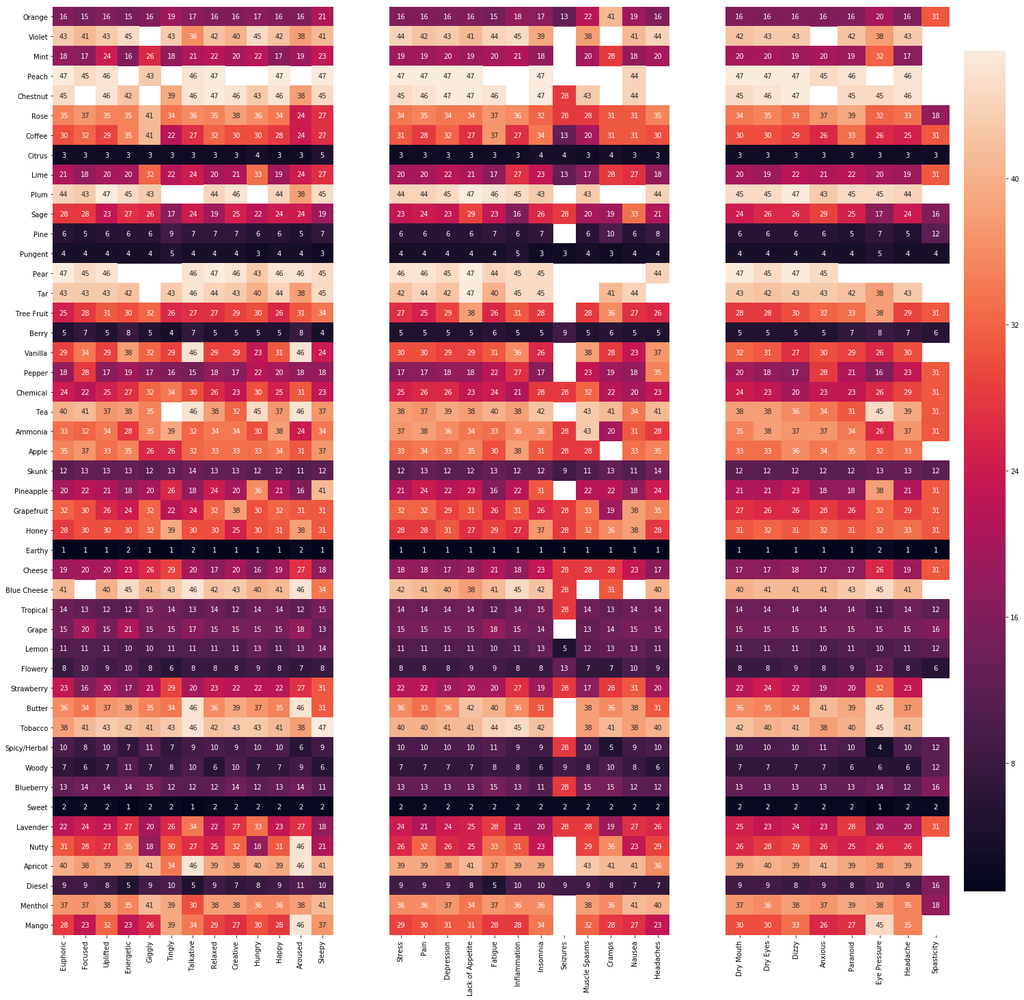

```python
import seaborn as sns

fig3, ax = plt.subplots(1, 3, figsize=(25,25))

sns.heatmap(rank_df[positives], vmin=1, vmax=47, annot=True, fmt='.0f', ax=ax[0], cbar=False)
sns.heatmap(rank_df[medical], vmin=1, vmax=47, annot=True, fmt='.0f', ax=ax[1], cbar=False, yticklabels=False)
sns.heatmap(rank_df[negatives], vmin=1, vmax=47, annot=True, fmt='.0f', ax=ax[2], yticklabels=False)
plt.show()
```

As we can see, the rank is generally constant across rows, likely owing to the fact that some flavours, like `Sweet`, `Earthy`, and `Citrus` are all heavily overrepresented in our dataset. Nonetheless, we can see that the `Seizures` column seems to deviate when it comes to `Spicy/Herbal`, `Blueberry`, `Tropical`, `Coffee`, and `Lime` flavours. To get a sense of how many actual samples there were for `Seizures` and the corresponding flavours, we can look at the column in our original `sum_df`, sorted by flavour name:

```python
sum_df['Seizures'].sort_index()
```

```
Ammonia          1.0
Apple            1.0
Apricot          NaN
Berry            3.0
Blue Cheese      1.0
Blueberry        1.0
Butter           NaN
Cheese           1.0
Chemical         1.0
Chestnut         1.0
Citrus           6.0
Coffee           2.0
Diesel           3.0
Earthy          18.0
Flowery          2.0
Grape            NaN
Grapefruit       1.0
Honey            1.0
Lavender         1.0
Lemon            5.0
Lime             2.0
Mango            NaN
Menthol          NaN
Mint             NaN
Nutty            NaN
Orange           2.0
Peach            NaN
Pear             NaN
Pepper           NaN
Pine             NaN
Pineapple        NaN
Plum             NaN
Pungent          7.0
Rose             1.0
Sage             1.0
Skunk            3.0
Spicy/Herbal     1.0
Strawberry       1.0
Sweet            9.0
Tar              NaN
Tea              NaN
Tobacco          NaN
Tree Fruit       NaN
Tropical         1.0
Vanilla          NaN
Violet           NaN
Woody            3.0
Name: Seizures, dtype: float64
```

## Association rule learning with Apriori

Finally, we can use association rule learning to examine which sets of properties appear frequently in our dataset, namely which flavours and effects tend to appear together more often than would be expected given their prevalence in the dataset. We can use the `apriori` algorithm from the `mlxtend` library for this.

```python
rule_df = df[medical+flavours]; rule_df.tail(5)
```

|  | Stress | Pain | Depression | Lack of Appetite | Fatigue | Inflammation | Insomnia | Seizures | Muscle Spasms | Cramps | ... | Spicy/Herbal | Woody | Blueberry | Sweet | Lavender | Nutty | Apricot | Diesel | Menthol | Mango |
| --- | --- | --- | --- | --- | --- | --- | --- | --- | --- | --- | --- | --- | --- | --- | --- | --- | --- | --- | --- | --- | --- |
| 2165 | 77.192982 | 47.368421 | 100.000000 | 0.000000 | 36.842105 | 0.000000 | 0.000000 | 0.0 | 0.000000 | 0.0 | ... | 0 | 0 | 0 | 1 | 0 | 0 | 0 | 0 | 0 | 0 |
| 2166 | 87.500000 | 100.000000 | 75.000000 | 0.000000 | 37.500000 | 0.000000 | 50.000000 | 0.0 | 0.000000 | 0.0 | ... | 0 | 1 | 0 | 0 | 0 | 0 | 0 | 1 | 0 | 0 |
| 2167 | 100.000000 | 30.729167 | 35.937500 | 18.229167 | 0.000000 | 19.791667 | 0.000000 | 0.0 | 0.000000 | 0.0 | ... | 0 | 0 | 0 | 0 | 1 | 0 | 0 | 0 | 0 | 0 |
| 2168 | 100.000000 | 0.000000 | 4.166667 | 0.000000 | 0.000000 | 4.166667 | 0.000000 | 0.0 | 8.333333 | 0.0 | ... | 0 | 0 | 0 | 1 | 0 | 0 | 0 | 0 | 0 | 0 |
| 2169 | 100.000000 | 74.289026 | 49.582149 | 0.000000 | 0.000000 | 0.000000 | 37.455669 | 0.0 | 0.000000 | 0.0 | ... | 0 | 1 | 0 | 0 | 0 | 0 | 0 | 0 | 0 | 0 |

5 rows × 59 columns

```python
rule_df = rule_df.astype('bool'); rule_df.tail(5)
```

|  | Stress | Pain | Depression | Lack of Appetite | Fatigue | Inflammation | Insomnia | Seizures | Muscle Spasms | Cramps | ... | Spicy/Herbal | Woody | Blueberry | Sweet | Lavender | Nutty | Apricot | Diesel | Menthol | Mango |
| --- | --- | --- | --- | --- | --- | --- | --- | --- | --- | --- | --- | --- | --- | --- | --- | --- | --- | --- | --- | --- | --- |
| 2165 | True | True | True | False | True | False | False | False | False | False | ... | False | False | False | True | False | False | False | False | False | False |
| 2166 | True | True | True | False | True | False | True | False | False | False | ... | False | True | False | False | False | False | False | True | False | False |
| 2167 | True | True | True | True | False | True | False | False | False | False | ... | False | False | False | False | True | False | False | False | False | False |
| 2168 | True | False | True | False | False | True | False | False | True | False | ... | False | False | False | True | False | False | False | False | False | False |
| 2169 | True | True | True | False | False | False | True | False | False | False | ... | False | True | False | False | False | False | False | False | False | False |

5 rows × 59 columns

```python
from mlxtend.frequent_patterns import apriori

frequent_itemsets = apriori(rule_df, min_support=0.3, use_colnames=True)
frequent_itemsets['length'] = frequent_itemsets['itemsets'].apply(lambda x: len(x))
frequent_itemsets
```

|  | support | itemsets | length |
| --- | --- | --- | --- |
| 0 | 0.869124 | (Stress) | 1 |
| 1 | 0.757604 | (Pain) | 1 |
| 2 | 0.818433 | (Depression) | 1 |
| 3 | 0.356221 | (Lack of Appetite) | 1 |
| 4 | 0.364977 | (Fatigue) | 1 |
| 5 | 0.463134 | (Insomnia) | 1 |
| 6 | 0.306912 | (Headaches) | 1 |
| 7 | 0.494470 | (Earthy) | 1 |
| 8 | 0.433180 | (Sweet) | 1 |
| 9 | 0.699539 | (Pain, Stress) | 2 |
| 10 | 0.752074 | (Stress, Depression) | 2 |
| 11 | 0.317051 | (Stress, Lack of Appetite) | 2 |
| 12 | 0.327650 | (Stress, Fatigue) | 2 |
| 13 | 0.415207 | (Stress, Insomnia) | 2 |
| 14 | 0.444700 | (Stress, Earthy) | 2 |
| 15 | 0.389862 | (Sweet, Stress) | 2 |
| 16 | 0.635945 | (Pain, Depression) | 2 |
| 17 | 0.372811 | (Pain, Insomnia) | 2 |
| 18 | 0.400000 | (Pain, Earthy) | 2 |
| 19 | 0.333641 | (Sweet, Pain) | 2 |
| 20 | 0.325806 | (Fatigue, Depression) | 2 |
| 21 | 0.377419 | (Insomnia, Depression) | 2 |
| 22 | 0.416129 | (Earthy, Depression) | 2 |
| 23 | 0.368664 | (Sweet, Depression) | 2 |
| 24 | 0.600000 | (Pain, Stress, Depression) | 3 |
| 25 | 0.344240 | (Pain, Stress, Insomnia) | 3 |
| 26 | 0.375115 | (Pain, Stress, Earthy) | 3 |
| 27 | 0.309677 | (Pain, Stress, Sweet) | 3 |
| 28 | 0.344240 | (Stress, Insomnia, Depression) | 3 |
| 29 | 0.389401 | (Earthy, Stress, Depression) | 3 |
| 30 | 0.344240 | (Sweet, Stress, Depression) | 3 |
| 31 | 0.301843 | (Pain, Insomnia, Depression) | 3 |
| 32 | 0.337327 | (Earthy, Pain, Depression) | 3 |
| 33 | 0.322581 | (Pain, Stress, Earthy, Depression) | 4 |

```python
frequent_itemsets[ (frequent_itemsets['length'] == 2)]
```

|  | support | itemsets | length |
| --- | --- | --- | --- |
| 9 | 0.699539 | (Pain, Stress) | 2 |
| 10 | 0.752074 | (Stress, Depression) | 2 |
| 11 | 0.317051 | (Stress, Lack of Appetite) | 2 |
| 12 | 0.327650 | (Stress, Fatigue) | 2 |
| 13 | 0.415207 | (Stress, Insomnia) | 2 |
| 14 | 0.444700 | (Stress, Earthy) | 2 |
| 15 | 0.389862 | (Sweet, Stress) | 2 |
| 16 | 0.635945 | (Pain, Depression) | 2 |
| 17 | 0.372811 | (Pain, Insomnia) | 2 |
| 18 | 0.400000 | (Pain, Earthy) | 2 |
| 19 | 0.333641 | (Sweet, Pain) | 2 |
| 20 | 0.325806 | (Fatigue, Depression) | 2 |
| 21 | 0.377419 | (Insomnia, Depression) | 2 |
| 22 | 0.416129 | (Earthy, Depression) | 2 |
| 23 | 0.368664 | (Sweet, Depression) | 2 |

```python
from mlxtend.frequent_patterns import association_rules

rules = association_rules(frequent_itemsets, metric="confidence", min_threshold=0.7); rules.sort_values('confidence', ascending=False)
```

|  | antecedents | consequents | antecedent support | consequent support | support | confidence | lift | leverage | conviction |
| --- | --- | --- | --- | --- | --- | --- | --- | --- | --- |
| 46 | (Depression, Pain, Earthy) | (Stress) | 0.337327 | 0.869124 | 0.322581 | 0.956284 | 1.100285 | 0.029401 | 2.993779 |
| 19 | (Pain, Depression) | (Stress) | 0.635945 | 0.869124 | 0.600000 | 0.943478 | 1.085550 | 0.047285 | 2.315491 |
| 26 | (Pain, Earthy) | (Stress) | 0.400000 | 0.869124 | 0.375115 | 0.937788 | 1.079003 | 0.027465 | 2.103704 |
| 36 | (Depression, Earthy) | (Stress) | 0.416129 | 0.869124 | 0.389401 | 0.935770 | 1.076681 | 0.027733 | 2.037597 |
| 39 | (Sweet, Depression) | (Stress) | 0.368664 | 0.869124 | 0.344240 | 0.933750 | 1.074357 | 0.023825 | 1.975480 |
| 29 | (Sweet, Pain) | (Stress) | 0.333641 | 0.869124 | 0.309677 | 0.928177 | 1.067945 | 0.019702 | 1.822191 |
| 23 | (Pain, Insomnia) | (Stress) | 0.372811 | 0.869124 | 0.344240 | 0.923362 | 1.062405 | 0.020220 | 1.707715 |
| 0 | (Pain) | (Stress) | 0.757604 | 0.869124 | 0.699539 | 0.923358 | 1.062400 | 0.041087 | 1.707615 |
| 3 | (Depression) | (Stress) | 0.818433 | 0.869124 | 0.752074 | 0.918919 | 1.057293 | 0.040753 | 1.614132 |
| 33 | (Insomnia, Depression) | (Stress) | 0.377419 | 0.869124 | 0.344240 | 0.912088 | 1.049433 | 0.016215 | 1.488710 |
| 8 | (Sweet) | (Stress) | 0.433180 | 0.869124 | 0.389862 | 0.900000 | 1.035525 | 0.013375 | 1.308756 |
| 7 | (Earthy) | (Stress) | 0.494470 | 0.869124 | 0.444700 | 0.899348 | 1.034774 | 0.014944 | 1.300273 |
| 5 | (Fatigue) | (Stress) | 0.364977 | 0.869124 | 0.327650 | 0.897727 | 1.032910 | 0.010439 | 1.279672 |
| 6 | (Insomnia) | (Stress) | 0.463134 | 0.869124 | 0.415207 | 0.896517 | 1.031518 | 0.012687 | 1.264711 |
| 14 | (Fatigue) | (Depression) | 0.364977 | 0.818433 | 0.325806 | 0.892677 | 1.090714 | 0.027097 | 1.691776 |
| 4 | (Lack of Appetite) | (Stress) | 0.356221 | 0.869124 | 0.317051 | 0.890039 | 1.024064 | 0.007450 | 1.190198 |
| 38 | (Sweet, Stress) | (Depression) | 0.389862 | 0.818433 | 0.344240 | 0.882979 | 1.078865 | 0.025164 | 1.551571 |
| 35 | (Stress, Earthy) | (Depression) | 0.444700 | 0.818433 | 0.389401 | 0.875648 | 1.069907 | 0.025443 | 1.460100 |
| 2 | (Stress) | (Depression) | 0.869124 | 0.818433 | 0.752074 | 0.865323 | 1.057293 | 0.040753 | 1.348169 |
| 45 | (Pain, Stress, Earthy) | (Depression) | 0.375115 | 0.818433 | 0.322581 | 0.859951 | 1.050728 | 0.015574 | 1.296451 |
| 18 | (Pain, Stress) | (Depression) | 0.699539 | 0.818433 | 0.600000 | 0.857708 | 1.047987 | 0.027474 | 1.276011 |
| 17 | (Sweet) | (Depression) | 0.433180 | 0.818433 | 0.368664 | 0.851064 | 1.039870 | 0.014135 | 1.219092 |
| 27 | (Stress, Earthy) | (Pain) | 0.444700 | 0.757604 | 0.375115 | 0.843523 | 1.113410 | 0.038208 | 1.549089 |
| 43 | (Pain, Earthy) | (Depression) | 0.400000 | 0.818433 | 0.337327 | 0.843318 | 1.030405 | 0.009954 | 1.158824 |
| 16 | (Earthy) | (Depression) | 0.494470 | 0.818433 | 0.416129 | 0.841566 | 1.028264 | 0.011438 | 1.146007 |
| 9 | (Pain) | (Depression) | 0.757604 | 0.818433 | 0.635945 | 0.839416 | 1.025638 | 0.015897 | 1.130666 |
| 24 | (Stress, Insomnia) | (Pain) | 0.415207 | 0.757604 | 0.344240 | 0.829079 | 1.094344 | 0.029677 | 1.418176 |
| 32 | (Stress, Insomnia) | (Depression) | 0.415207 | 0.818433 | 0.344240 | 0.829079 | 1.013007 | 0.004420 | 1.062284 |
| 47 | (Depression, Stress, Earthy) | (Pain) | 0.389401 | 0.757604 | 0.322581 | 0.828402 | 1.093451 | 0.027569 | 1.412585 |
| 15 | (Insomnia) | (Depression) | 0.463134 | 0.818433 | 0.377419 | 0.814925 | 0.995714 | -0.001625 | 0.981047 |
| 44 | (Depression, Earthy) | (Pain) | 0.416129 | 0.757604 | 0.337327 | 0.810631 | 1.069994 | 0.022066 | 1.280023 |
| 41 | (Pain, Insomnia) | (Depression) | 0.372811 | 0.818433 | 0.301843 | 0.809642 | 0.989258 | -0.003278 | 0.953815 |
| 12 | (Earthy) | (Pain) | 0.494470 | 0.757604 | 0.400000 | 0.808947 | 1.067771 | 0.025388 | 1.268738 |
| 48 | (Pain, Earthy) | (Stress, Depression) | 0.400000 | 0.752074 | 0.322581 | 0.806452 | 1.072304 | 0.021751 | 1.280952 |
| 11 | (Insomnia) | (Pain) | 0.463134 | 0.757604 | 0.372811 | 0.804975 | 1.062528 | 0.021939 | 1.242899 |
| 1 | (Stress) | (Pain) | 0.869124 | 0.757604 | 0.699539 | 0.804878 | 1.062400 | 0.041087 | 1.242281 |
| 42 | (Insomnia, Depression) | (Pain) | 0.377419 | 0.757604 | 0.301843 | 0.799756 | 1.055639 | 0.015909 | 1.210504 |
| 20 | (Stress, Depression) | (Pain) | 0.752074 | 0.757604 | 0.600000 | 0.797794 | 1.053049 | 0.030226 | 1.198760 |
| 40 | (Sweet) | (Stress, Depression) | 0.433180 | 0.752074 | 0.344240 | 0.794681 | 1.056653 | 0.018457 | 1.207517 |
| 30 | (Sweet, Stress) | (Pain) | 0.389862 | 0.757604 | 0.309677 | 0.794326 | 1.048472 | 0.014317 | 1.178548 |
| 21 | (Pain) | (Stress, Depression) | 0.757604 | 0.752074 | 0.600000 | 0.791971 | 1.053049 | 0.030226 | 1.191786 |
| 37 | (Earthy) | (Stress, Depression) | 0.494470 | 0.752074 | 0.389401 | 0.787512 | 1.047120 | 0.017523 | 1.166776 |
| 10 | (Depression) | (Pain) | 0.818433 | 0.757604 | 0.635945 | 0.777027 | 1.025638 | 0.015897 | 1.087111 |
| 50 | (Depression, Earthy) | (Pain, Stress) | 0.416129 | 0.699539 | 0.322581 | 0.775194 | 1.108149 | 0.031482 | 1.336533 |
| 13 | (Sweet) | (Pain) | 0.433180 | 0.757604 | 0.333641 | 0.770213 | 1.016643 | 0.005462 | 1.054873 |
| 28 | (Earthy) | (Pain, Stress) | 0.494470 | 0.699539 | 0.375115 | 0.758621 | 1.084458 | 0.029214 | 1.244766 |
| 34 | (Insomnia) | (Stress, Depression) | 0.463134 | 0.752074 | 0.344240 | 0.743284 | 0.988312 | -0.004071 | 0.965759 |
| 25 | (Insomnia) | (Pain, Stress) | 0.463134 | 0.699539 | 0.344240 | 0.743284 | 1.062533 | 0.020260 | 1.170400 |
| 22 | (Depression) | (Pain, Stress) | 0.818433 | 0.699539 | 0.600000 | 0.733108 | 1.047987 | 0.027474 | 1.125777 |
| 49 | (Stress, Earthy) | (Pain, Depression) | 0.444700 | 0.635945 | 0.322581 | 0.725389 | 1.140647 | 0.039776 | 1.325711 |
| 31 | (Sweet) | (Pain, Stress) | 0.433180 | 0.699539 | 0.309677 | 0.714894 | 1.021949 | 0.006651 | 1.053855 |